# The Movie Database

```python
# import libraries used throughout notebook

# import pandas
import pandas as pd

# import numpy
import numpy as np

# import pyplot
import matplotlib.pyplot as plt

# import seaborn
import seaborn as sns
sns.set()

# import sklearn linear regression
from sklearn.linear_model import LinearRegression
```

## References

Below are a list of references used in the analysis, as well as links to the location in the notebook these references were utilised:

Simple linear regression implemented to predict zero values: (Notebook Link)

https://analyticsindiamag.com/5-ways-handle-missing-values-machine-learning-datasets/

Use Seaborn regplot to plot scatter with linear regression: (Notebook Link)

https://seaborn.pydata.org/generated/seaborn.regplot.html

Use Seaborn colour wheel for multiple plots: (Notebook Link)

https://seaborn.pydata.org/generated/seaborn.color_palette.html

Use Seaborn joint plot to plot scatter and histogram in one plot: (Notebook Link)

https://seaborn.pydata.org/tutorial/distributions.html

Back/Front Fill NaN: (Notebook Link)

https://stackoverflow.com/questions/27905295/how-to-replace-nans-by-preceding-values-in-pandas-dataframe

## The Data Set

Data was provided by The Movie Database (tMDB)

The csv file as a basis for this analysis can be downloaded through the following link:

https://d17h27t6h515a5.cloudfront.net/topher/2017/October/59dd1c4c_tmdb-movies/tmdb-movies.csv

## Questions

Stated below are the set of questions which the report will aim to answer, as well as the broad steps taken to come to conclusions. Detailed steps are documented under each question heading.

### Questions regarding popularity and profitability:

Are popularity and profitability postively correlated?

It could be easy to assume that the more popular a movie the hgiher the profitability, however it may be the case that popular movies simply have a higher budget without the corresponding revenues. Once it this relationship is establish we will investigate how columns in the database affect popularity and profitability.

```
1. Plot scatter graph of popularity vs profitability containing linear regression
```

### Questions regarding popularity:

How do the average popularity scores of each genre compare?

```
1. Create dataFrame containing mean popularity for each distinct genre
2. Sort dataFrame in descending order
3. Plot bar graph popularity by genre
```

How does release year affect popularity?

```
1. Create dataFrame containing mean and median popularity for each release year
2. Plot line graph of mean and median popularity by release year
```

How does release year affect mean genre popularity?

```
1. Create dataFrame containing mean popularity with release year/genre as column/index
2. Create line graph for each genre as subplots
```

How does run time affect popularity?

```
1. Create dataFrame containing movie popularity and runtime
2. Plot scatter graph
```

### Questions regarding profitability:

How do the number of genres affect profitability?

```
1. Iterate through the columns listed above
2. Create dataFrame for each unique number of genres/cast members/production companies over each iteration
3. Create bar graph over each iteration
```

Which production companies are associated with the highest profiting movies?

```
1. Create dataFrame containing 20 most profitable movies
2. Plot bar graph profitablity by production company
```

What is the most profitable movie of all time?

```
1. Search dataFrame for most profitable movie
```

## Data Wrangling

For further information of each of the fields used in this analysis follow this link:

https://developers.themoviedb.org/3/getting-started/introduction

#### Core Features of Interest

1. **id:** TMDB movie id
2. **popularity:** the popularity score given to a movie is a function of todays views and votes as well as the previous days populairty score. It is therefore a current popularity score rather than an all time popularity score.
3. **original_title**: title of movie
4. **budget_adj:** more useful comparison metric than budget for movies over many years
5. **revenue_adj:** more useful comparison metric than budget for movies over many years
6. **cast:** lead roles in move
7. **director:** director(s) of movie
8. **runtime:** run time of movie
9. **genres:** genres of movie
10. **production_companies:** production company associated with movie
11. **release_year Year:** year of release

#### New Features Added

1. **profitabilty_adj = (revenue_adj - budget_adj):** this feature gives an indicator of profitability, assuming budget is close to spend
2. **num_genres:** number of genres associated with the movie
3. **num_production_companies:** number of production companies associated with the movie
4. **num_directors:** number of directors associated with the movie
5. **num_cast:** number of cast members associated with the movie

```python
# read csv files into dataFrames
df = pd.read_csv('tmdb-movies.csv', delimiter=',')
```

```python
# check data table has imported correctly
df.head()
```

|  | id | imdb_id | popularity | budget | revenue | original_title | cast | homepage | director | tagline | ... | overview | runtime | genres | production_companies | release_date | vote_count | vote_average | release_year | budget_adj | revenue_adj |
| --- | --- | --- | --- | --- | --- | --- | --- | --- | --- | --- | --- | --- | --- | --- | --- | --- | --- | --- | --- | --- | --- |
| 0 | 135397 | tt0369610 | 32.985763 | 150000000 | 1513528810 | Jurassic World | Chris Pratt\|Bryce Dallas Howard\|Irrfan Khan\|Vi... | http://www.jurassicworld.com/ | Colin Trevorrow | The park is open. | ... | Twenty-two years after the events of Jurassic ... | 124 | Action\|Adventure\|Science Fiction\|Thriller | Universal Studios\|Amblin Entertainment\|Legenda... | 6/9/15 | 5562 | 6.5 | 2015 | 1.379999e+08 | 1.392446e+09 |
| 1 | 76341 | tt1392190 | 28.419936 | 150000000 | 378436354 | Mad Max: Fury Road | Tom Hardy\|Charlize Theron\|Hugh Keays-Byrne\|Nic... | http://www.madmaxmovie.com/ | George Miller | What a Lovely Day. | ... | An apocalyptic story set in the furthest reach... | 120 | Action\|Adventure\|Science Fiction\|Thriller | Village Roadshow Pictures\|Kennedy Miller Produ... | 5/13/15 | 6185 | 7.1 | 2015 | 1.379999e+08 | 3.481613e+08 |
| 2 | 262500 | tt2908446 | 13.112507 | 110000000 | 295238201 | Insurgent | Shailene Woodley\|Theo James\|Kate Winslet\|Ansel... | http://www.thedivergentseries.movie/#insurgent | Robert Schwentke | One Choice Can Destroy You | ... | Beatrice Prior must confront her inner demons ... | 119 | Adventure\|Science Fiction\|Thriller | Summit Entertainment\|Mandeville Films\|Red Wago... | 3/18/15 | 2480 | 6.3 | 2015 | 1.012000e+08 | 2.716190e+08 |
| 3 | 140607 | tt2488496 | 11.173104 | 200000000 | 2068178225 | Star Wars: The Force Awakens | Harrison Ford\|Mark Hamill\|Carrie Fisher\|Adam D... | http://www.starwars.com/films/star-wars-episod... | J.J. Abrams | Every generation has a story. | ... | Thirty years after defeating the Galactic Empi... | 136 | Action\|Adventure\|Science Fiction\|Fantasy | Lucasfilm\|Truenorth Productions\|Bad Robot | 12/15/15 | 5292 | 7.5 | 2015 | 1.839999e+08 | 1.902723e+09 |
| 4 | 168259 | tt2820852 | 9.335014 | 190000000 | 1506249360 | Furious 7 | Vin Diesel\|Paul Walker\|Jason Statham\|Michelle ... | http://www.furious7.com/ | James Wan | Vengeance Hits Home | ... | Deckard Shaw seeks revenge against Dominic Tor... | 137 | Action\|Crime\|Thriller | Universal Pictures\|Original Film\|Media Rights ... | 4/1/15 | 2947 | 7.3 | 2015 | 1.747999e+08 | 1.385749e+09 |

5 rows × 21 columns

#### Drop columns not of interest

```python
# drop columns not required to answer questions
drop_columns = ['imdb_id', 'budget', 'revenue', 'homepage', 'tagline', 'keywords', 'overview', 'release_date','vote_count','vote_average']
df = df.drop(columns = drop_columns)
```

#### Set Index to 'id'

```python
# add the number of genres, prod companies, cast members and directors as a column in the database
df.set_index('id', inplace=True)
```

#### Clean Data

```python
df.dropna(inplace = True);
```

##### Removing Duplicates

```python
# count duplicate rows/movies
print('Number of duplicate rows before removal: ' + str(df.duplicated().sum()))
print('Number of duplicate movies before removal: ' + str(df['original_title'].duplicated().sum()))

# remove duplicate rows from dataFrame
df.drop_duplicates(inplace = True)

# remove duplicate movies from dataFrame
df.drop_duplicates(subset = 'original_title', inplace = True)

# count duplicate rows/movies
print('Number of duplicate rows after removal: ' + str(df.duplicated().sum()))
print('Number of duplicate movies after removal: ' + str(df['original_title'].duplicated().sum()))
```

```
Number of duplicate rows before removal: 1
Number of duplicate movies before removal: 261
Number of duplicate rows after removal: 0
Number of duplicate movies after removal: 0
```

#### Zero Values

```python
print('Number of zero valued budget rows: ' + str((df['budget_adj']==0).sum()))
print('Number of zero valued revenue rows: ' + str((df['revenue_adj']==0).sum()))

# repleace zero values with NaN so we can use replace na
df['budget_adj'] = df['budget_adj'].replace(0, np.NaN)
df['revenue_adj'] = df['revenue_adj'].replace(0, np.NaN)
```

```
Number of zero valued budget rows: 4615
Number of zero valued revenue rows: 4872
```

The data set is large so imputing NaN values with the mean/median/mode is not appropriate.

There are also a very large percentage of null values.

To calculate an estimate for zero values implement Linear Regression Model

```python
# define columns to be used in linear regression models
df_genres = df['genres'].str.get_dummies('|')
df_forLR = df[['runtime', 'release_year', 'budget_adj', 'revenue_adj']].merge(df_genres, left_index = True, right_index = True)
df_forLR.drop_duplicates()

budget_columns = df_genres.columns.tolist()
budget_columns.extend(['runtime', 'release_year', 'budget_adj'])

revenue_columns = df_genres.columns.tolist()
revenue_columns.extend(['runtime', 'release_year', 'revenue_adj'])
```

```python
# implement simple linear regression to predict zero values for NaN
budget_linreg = LinearRegression()

budget_data_with_null = df_forLR[budget_columns]

budget_data_without_null = budget_data_with_null.dropna()

train_budget_data_x = budget_data_without_null.iloc[:,:21]
train_budget_data_y = budget_data_without_null.iloc[:,21]

budget_linreg.fit(train_budget_data_x, train_budget_data_y)

budget_test_data = budget_data_with_null.iloc[:,:21]

budget_predicted = pd.Series(budget_linreg.predict(budget_test_data))

budget_predicted.index = df.index

# replace missing values
df['budget_adj'].fillna(budget_predicted, inplace = True)
```

```python
# implement simple linear regression to predict zero values for NaN
revenue_linreg  = LinearRegression()

revenue_data_with_null = df_forLR[revenue_columns]

revenue_data_without_null = revenue_data_with_null.dropna()

train_revenue_data_x = revenue_data_without_null.iloc[:,:21]
train_revenue_data_y = revenue_data_without_null.iloc[:,21]

revenue_linreg.fit(train_revenue_data_x, train_revenue_data_y)

revenue_test_data = revenue_data_with_null.iloc[:,:21]

revenue_predicted = pd.Series(revenue_linreg.predict(revenue_test_data))

revenue_predicted.index = df.index

# replace missing values
df['revenue_adj'].fillna(revenue_predicted, inplace = True)
```

```python
print('Number of zero valued budget rows: ' + str((df['budget_adj']==0).sum()))
print('Number of zero valued revenue rows: ' + str((df['revenue_adj']==0).sum()))
```

```
Number of zero valued budget rows: 0
Number of zero valued revenue rows: 0
```

```python
# check that each column has an entry for every row of the dataset
df.info()
```

```
<class 'pandas.core.frame.DataFrame'>
Int64Index: 9512 entries, 135397 to 22293
Data columns (total 10 columns):
popularity              9512 non-null float64
original_title          9512 non-null object
cast                    9512 non-null object
director                9512 non-null object
runtime                 9512 non-null int64
genres                  9512 non-null object
production_companies    9512 non-null object
release_year            9512 non-null int64
budget_adj              9512 non-null float64
revenue_adj             9512 non-null float64
dtypes: float64(3), int64(2), object(5)
memory usage: 1.1+ MB
```

#### Creaete New Data Frames for Analysis

There is a common problem in the dataset, which will make analysis difficult unless we find a different way of structuring the data. Within one row of data (one movie) there may be many genres, production companies, cast members and even directors which are represented as a list seperated by a pipe symbol | e.g. for the movie id 135397 the column genres has a list of genres as follows:

```python
df.loc[135397][['genres']]
```

```
genres    Action|Adventure|Science Fiction|Thriller
Name: 135397, dtype: object
```

To better analyse, four distinct dataFrames

```python
# create dataFrames for analysis
df_genres = df['genres'].str.get_dummies('|')
df_production_companies = df['production_companies'].str.get_dummies('|')
df_cast = df['cast'].str.get_dummies('|')
df_directors = df['director'].str.get_dummies('|')
```

These data frames are of the format:

```python
df_genres.head()
```

| id | Action | Adventure | Animation | Comedy | Crime | Documentary | Drama | Family | Fantasy | Foreign | History | Horror | Music | Mystery | Romance | Science Fiction | TV Movie | Thriller | War | Western |
| --- | --- | --- | --- | --- | --- | --- | --- | --- | --- | --- | --- | --- | --- | --- | --- | --- | --- | --- | --- | --- |
| 135397 | 1 | 1 | 0 | 0 | 0 | 0 | 0 | 0 | 0 | 0 | 0 | 0 | 0 | 0 | 0 | 1 | 0 | 1 | 0 | 0 |
| 76341 | 1 | 1 | 0 | 0 | 0 | 0 | 0 | 0 | 0 | 0 | 0 | 0 | 0 | 0 | 0 | 1 | 0 | 1 | 0 | 0 |
| 262500 | 0 | 1 | 0 | 0 | 0 | 0 | 0 | 0 | 0 | 0 | 0 | 0 | 0 | 0 | 0 | 1 | 0 | 1 | 0 | 0 |
| 140607 | 1 | 1 | 0 | 0 | 0 | 0 | 0 | 0 | 1 | 0 | 0 | 0 | 0 | 0 | 0 | 1 | 0 | 0 | 0 | 0 |
| 168259 | 1 | 0 | 0 | 0 | 1 | 0 | 0 | 0 | 0 | 0 | 0 | 0 | 0 | 0 | 0 | 0 | 0 | 1 | 0 | 0 |

From here we can join back to the original dataFrame to help answer the questions posed.

#### Add New Features

```python
# add profitability as a new feature
df['profitability_adj'] = df['revenue_adj'] - df['budget_adj'];
```

```python
# add num_genres, num_production_companies and num_cast as a new features
df['num_genres'] = df_genres.sum(axis=1)
df['num_production_companies'] = df_production_companies.sum(axis=1)
df['num_cast'] = df_cast.sum(axis=1)
```

## Exploration

### General Exploration

```python
# how many genres, production companies, cast members and directors are present in the database
print('There are ' + str(len(df_genres.columns.tolist())) + ' distinct genres')
print('There are ' + str(len(df_production_companies.columns.unique().tolist())) + ' distinct production companies')
print('There are ' + str(len(df_cast.columns.unique().tolist())) + ' distinct cast members')
print('There are ' + str(len(df_directors.columns.unique().tolist())) + ' distinct directors')
```

```
There are 20 distinct genres
There are 7701 distinct production companies
There are 16817 distinct cast members
There are 4696 distinct directors
```

```python
# general statistics on numerical data in main dataFrame
df.describe()
```

|  | popularity | runtime | release_year | budget_adj | revenue_adj | profitability_adj | num_genres | num_production_companies | num_cast |
| --- | --- | --- | --- | --- | --- | --- | --- | --- | --- |
| count | 9512.000000 | 9512.000000 | 9512.000000 | 9.512000e+03 | 9.512000e+03 | 9.512000e+03 | 9512.000000 | 9512.000000 | 9512.000000 |
| mean | 0.697204 | 102.708894 | 2001.198802 | 1.954108e+07 | 5.717277e+07 | 3.763169e+07 | 2.516611 | 2.373213 | 4.911060 |
| std | 1.044546 | 26.512430 | 12.832318 | 3.583899e+07 | 1.521247e+08 | 1.320629e+08 | 1.110704 | 1.345682 | 0.483864 |
| min | 0.000188 | 0.000000 | 1960.000000 | 9.210911e-01 | 2.370705e+00 | -4.139124e+08 | 1.000000 | 1.000000 | 1.000000 |
| 25% | 0.232403 | 90.000000 | 1994.000000 | 2.002335e+03 | 2.001662e+03 | -2.082312e+00 | 2.000000 | 1.000000 | 5.000000 |
| 50% | 0.420687 | 100.000000 | 2005.000000 | 3.457540e+05 | 2.007966e+03 | 2.981201e-03 | 2.000000 | 2.000000 | 5.000000 |
| 75% | 0.778477 | 112.000000 | 2011.000000 | 2.500000e+07 | 4.305135e+07 | 2.013431e+07 | 3.000000 | 3.000000 | 5.000000 |
| max | 32.985763 | 705.000000 | 2015.000000 | 4.250000e+08 | 2.827124e+09 | 2.750137e+09 | 5.000000 | 5.000000 | 5.000000 |

```python
# Set colour
colour = sns.color_palette("Blues_d")[1]
```

### Is there correlation between popularity and profitability?

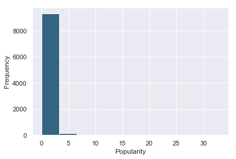

```python
# plot histogram for popularity
df['popularity'].hist(bins = 10, color = colour);
plt.title('');
plt.xlabel('Popularity');
plt.ylabel('Frequency');
```

A very high percentage movies in the database get a low popularity rating. Only a very small percentage of movies recieve a high popularity rating.

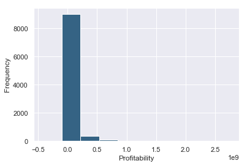

```python
# plot histogram for budget_adj
df['profitability_adj'].hist(bins = 10, color = colour);
plt.title('');
plt.xlabel('Profitability');
plt.ylabel('Frequency');
```

A very high number of movies are loss making or marginally profitable. Only a very small number of movies make more than 0.4x10e9.

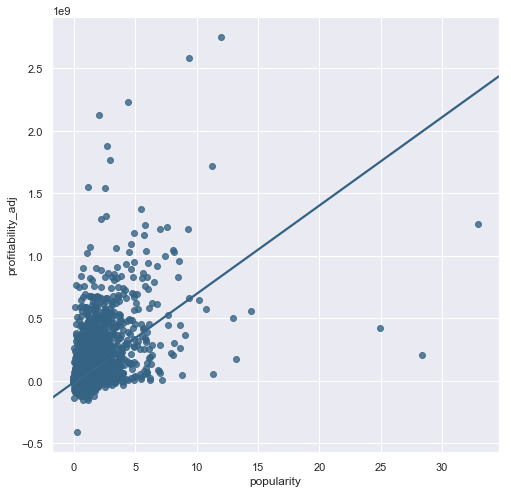

```python
# plot the relationship between popularity and profitability
colour = sns.color_palette("Blues_d")[1]
plt.figure(figsize=(8,8));
sns.regplot(df['popularity'],df['profitability_adj'], ci=0, x_jitter=0.1, y_jitter=0.3, color = colour);
```

Correlation between popularity and profitability clearly demonstrated in the graph above. Causation is not, which is looked at in the rest of this report.

Plot Used: Linear regression used to clearly show correlation. Although positive correlation is clear, the gradient of this correlation is not due to the variation in the data points.

##### (Skip to Conclusions for this question)

### How do the average popularity scores of each genre compare?

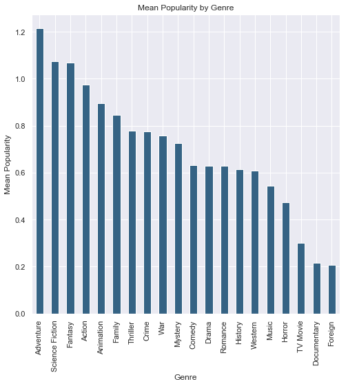

```python
# Merge genres dataFrame to main dataFrame by movie id to determine mean genre popularity
df_genre_populatiry_ones = df[['popularity']].dot(np.ones((1,len(df_genres.columns))))
df_genre_populatiry_ones.columns = df_genres.columns
df_genre_populatiry = df_genres * df_genre_populatiry_ones
df_genre_populatiry = df_genre_populatiry.replace(0, np.NaN)
df_genre_populatiry_mean = df_genre_populatiry.mean().sort_values(ascending = False)

# create bar plot
df_genre_populatiry_mean.plot(kind = 'bar', figsize = (8,8), color = colour);
plt.title('Mean Popularity by Genre');
plt.xlabel('Genre');
plt.ylabel('Mean Popularity');
```

Plot Used: Data sorted within bar plot to clearly show genre with max popularity descending to genre with min popularity

##### (Skip to Conclusions for this question)

### How does release year affect popularity?

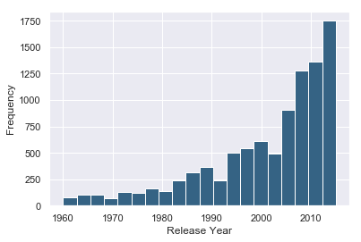

```python
df['release_year'].hist(bins = 20, color = colour);
plt.title('');
plt.xlabel('Release Year');
plt.ylabel('Frequency');
```

The more current the release year the more movies TMDB will have on record.

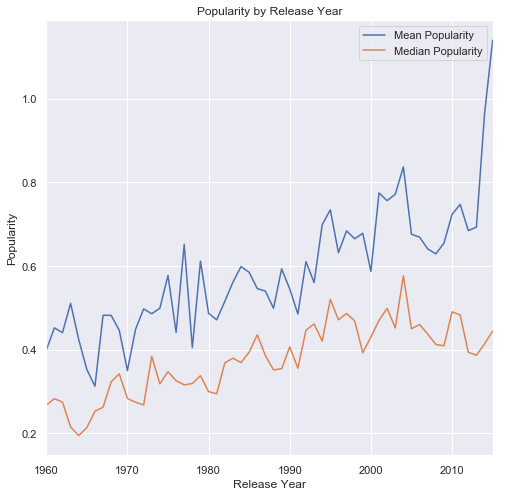

```python
# scatter plot popularity vs release_year
df_ryear_populatiry = df[['popularity', 'release_year']].groupby('release_year').agg(['mean','median'])
df_ryear_populatiry.plot(kind='line', figsize = (8,8));

plt.title('Popularity by Release Year');
plt.xlabel('Release Year');
plt.ylabel('Popularity');
plt.legend(['Mean Popularity','Median Popularity']);
```

Both mean and median popularity increase with release year. Mean popularity is always greater than median popularity.

Plot Used: Mean and median displayed to get a sense of skew within the data. Line plot is the most appropriate plot as there are distinct mean and median values for each release year. Also we want to give an indication of how popularity is changing over time, which is better done with a line graph over a scatter graph.

##### (Skip to Conclusions for this question)

### How does release year affect mean genre popularity?

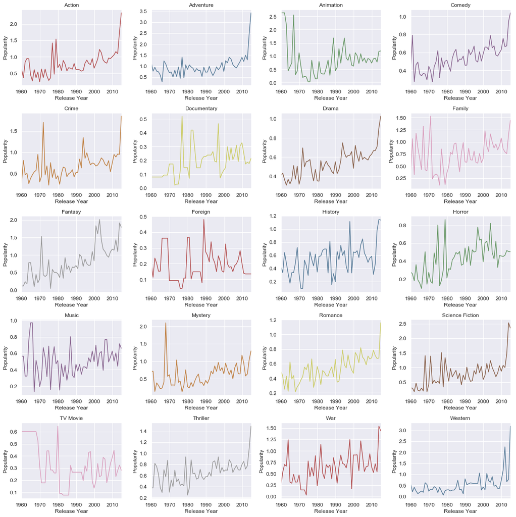

```python
#
df_genre_year_populatiry = df_genre_populatiry.merge(df[['release_year']], left_index = True, right_index = True)
df_genre_year_populatiry_mean = df_genre_year_populatiry.groupby('release_year').mean()

# genre, years with no movies return NaN in the above lambda function, front/backfill NaN
df_genre_year_populatiry_mean.fillna(method = 'ffill', inplace = True)
df_genre_year_populatiry_mean.fillna(method = 'bfill', inplace = True)

# plot line graphs to show how each genre popularity has varied over time
colours = sns.color_palette("Set1", n_colors=len(df_genres.columns), desat=.5)

for i, genre in enumerate(df_genre_year_populatiry_mean.columns.tolist()):
    plt.subplot(5, 4, i+1)
    plt.tight_layout()
    df_genre_year_populatiry_mean[genre].plot(kind = 'line',  figsize = (16,16), fontsize = 12, color = colours[i]);
    plt.title('{}'.format(genre), fontsize=12)
    plt.xlabel('Release Year', fontsize = 12);
    plt.ylabel('Popularity', fontsize = 12);
```

Plot Used: Used 5x4 grid of plots so user can visually identify trend in each genre. Over plotting 20 lines onto one graph was visually messy.

##### (Skip to Conclusions for this question)

### How does run time affect popularity?

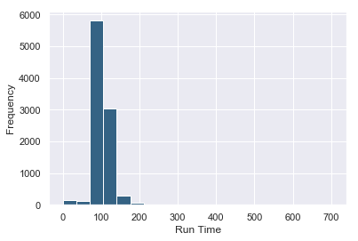

```python
df['runtime'].hist(bins = 20, color = colour);
plt.title('');
plt.xlabel('Run Time');
plt.ylabel('Frequency');
```

A high percentage of the movies in the dataset are centred around 100 minutes long

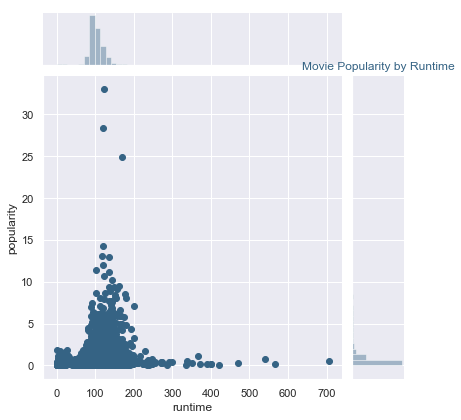

```python
# scatter plot to see relationship between runtime and popularity
sns.jointplot(x = 'runtime', y = 'popularity', data=df, color = colour);
plt.title('Movie Popularity by Runtime', loc = 'center', color = colour);
```

Plot Used: Scatter plot the best visualisation to explore bi-variate data with many unconnected data points. Histograms included to give a clear visulization as to where the majority of the data points lie.

##### (Skip to Conclusions for this question)

### How does the number of genres affect profitabiltiy?

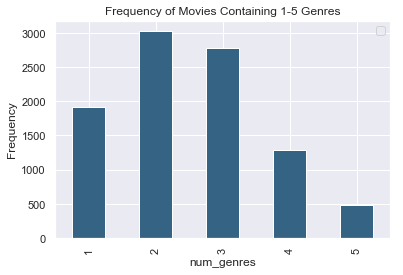

```python
# plot bar chart of frequency and num_genres
df[['num_genres','release_year']].groupby('num_genres').count().plot(kind='bar', color = colour);
plt.title('Frequency of Movies Containing 1-5 Genres');
plt.ylabel('Frequency');
plt.legend('');
```

```python
# show percentage of genres
df_num_genre_perc = df[['num_genres','release_year']].groupby('num_genres').count() * 100/ df['num_genres'].count()
df_num_genre_perc.columns = ['percentage']
df_num_genre_perc
```

| num_genres | percentage |
| --- | --- |
| 1 | 20.185029 |
| 2 | 31.843987 |
| 3 | 29.226241 |
| 4 | 13.614382 |
| 5 | 5.130362 |

Plot above shows frequency of movies encompassing 1-5 genres. 81% 1-3 genres with 19% 4-5 genres.

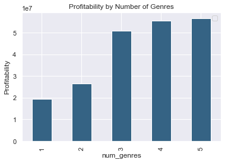

```python
# plot bar chart of profitability and num genres
df_num_genres_pop_mean = df[['profitability_adj', 'num_genres']].groupby('num_genres').mean()
df_num_genres_pop_mean.plot(kind='bar', figsize=(6,4), color = colour);
plt.title('Profitability by Number of Genres');
plt.ylabel('Profitability');
plt.legend('');
```

```python
df_num_genres_pop_mean_perc = df_num_genres_pop_mean / df_num_genres_pop_mean.sum()
df_num_genres_pop_mean_perc.columns = ['profitability_adj_percentage']
df_num_genres_pop_mean_perc
```

| num_genres | profitability_adj_percentage |
| --- | --- |
| 1 | 0.092523 |
| 2 | 0.127509 |
| 3 | 0.243279 |
| 4 | 0.265396 |
| 5 | 0.271294 |

Plot Used: Bar plot used as most approriate visualisation

##### (Skip to Conclusions for this question)

### Which production companies are associated with the highest profiting movies?

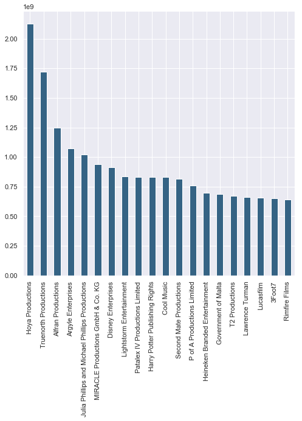

```python
# create dataFrame with unique list of directors and mean popularity
df_prodcomp_populatiry_ones = df[['profitability_adj']].dot(np.ones((1,len(df_production_companies.columns))))
df_prodcomp_populatiry_ones.columns = df_production_companies.columns
df_prodcomp_populatiry = df_production_companies * df_prodcomp_populatiry_ones
df_prodcomp_populatiry = df_prodcomp_populatiry.replace(0, np.NaN)
df_prodcomp_populatiry_mean = df_prodcomp_populatiry.mean().sort_values(ascending = False)

# sort descending and take top 20 rows
df_prod_comp_prof_top20 = df_prodcomp_populatiry_mean.sort_values(ascending = False)[0:20]

# plot bar chart
df_prod_comp_prof_top20.plot(kind='bar', figsize = (8,8), color = colour);
```

Plot Used: Data sorted within bar plot to clearly show production company with max profitability descending to genre with min profitability

##### (Skip to Conclusions for this question)

### What is the most profitable movie of all time?

```python
# df[df['profitability_adj'] == df['profitability_adj'].max()]['original_title'][0]
df[df['profitability_adj'] == df['profitability_adj'].max()]['original_title'].tolist()[0]
```

```
'Star Wars'
```

[figure not shown]

## Limitations

Another limitation of the data set was that many of the key fields that I was interested in analysing were listed in one column. For instance with 'Genre' there would be a list of genres associated with a movie in one column. This structure would make it impossible to analyse statistics based on individual genres. There are different ways in which the data could be structured. After experimenting with dataFrames which required for loops to create, I decided to utilise vector/matrix operations in numpy and pandas to achieve this as it made the code far more efficient to run.

The popularity feature provided is heavily weighted towards current popularity, rather than all time popularity. I think a more interesting analysis or complementary analaysis would be to look at all time popularity ratings.

## Conclusions

Throughout this section, the conclusions made will refer to graphs which can be found in the exploration section. The question headings link back to the corresponding section in the exploration section.

### Questions regarding popularity and profitability:

#### Are popularity and profitability postively correlated?

- There is clear positive correlation between profitability and popularity.
- This does not explain why a movie might be popular or profitable, simply that the higher the popularity the hgiher the profitability and visa verca.

The following questions all investigate other columns in the data set and their affect on popularity and profitability.

### Questions regarding popularity:

#### How do the average popularity scores of each genre compare?

- Can be derrived visually from plot, also listed below.

```python
df_genre_populatiry_mean
```

```
Adventure          1.214071
Science Fiction    1.075360
Fantasy            1.067159
Action             0.975493
Animation          0.896471
Family             0.846791
Thriller           0.779303
Crime              0.774826
War                0.756633
Mystery            0.726427
Comedy             0.632859
Drama              0.628193
Romance            0.628172
History            0.613689
Western            0.608272
Music              0.544727
Horror             0.473974
TV Movie           0.299245
Documentary        0.216160
Foreign            0.207008
dtype: float64
```

- It is important to note the the zero values filled using a linear regression may have impacted the results here. Of course when estimating a value we can never be certain that the estimation is accurate without attempting to gather the data from another source.

#### How does release year affect popularity?

- The greater the release year the greater the popularity. This is true for both mean and median popularity, although median popularity tails off slightly in more recent years. Intuitively this makes sense as the popularity score is a current rating that is calculated based on user activity over the last two days, rather than an all time popularity rating.
- Mean popularity is always higher than median popularity (skewed to right) which implies the movies with high popularity scores are dominant drawing the mean up.
- In general, over a 5-10 year period mean popularity does not deviate more than 0.2 although there is a noticeable spike in mean popularity from 2013-2015. The next question looks at if this particular trend holds true for all genres.
- The more current the release year the more movies TMDB have on record.

### Questions regarding profitability:

#### How do the number of genres affect profitability?

- Movies that ecompass 3 or more genres are more profitable than those that encompass 1-2 genres.
- Despite this fact, the vast majority of movies seem to encompass 1-3 genres, with fewer movies encompassing 4 and 5 genres.

#### Which production companies are associated with the highest profiting movies?

- Can be derrived visually from plot, also listed below.

```python
df_prod_comp_prof_top20
```

```
Hoya Productions                                   2.128036e+09
Truenorth Productions                              1.718723e+09
Alfran Productions                                 1.246626e+09
Argyle Enterprises                                 1.072786e+09
Julia Phillips and Michael Phillips Productions    1.021009e+09
MIRACLE Productions GmbH & Co. KG                  9.415495e+08
Disney Enterprises                                 9.134635e+08
Lightstorm Entertainment                           8.353534e+08
Patalex IV Productions Limited                     8.328680e+08
Harry Potter Publishing Rights                     8.289386e+08
Cool Music                                         8.289386e+08
Second Mate Productions                            8.157552e+08
P of A Productions Limited                         7.617083e+08
Heineken Branded Entertainment                     6.976982e+08
Government of Malta                                6.849560e+08
T2 Productions                                     6.724590e+08
Lawrence Turman                                    6.628089e+08
Lucasfilm                                          6.547382e+08
3Foot7                                             6.494795e+08
Rimfire Films                                      6.429831e+08
dtype: float64
```

#### What is the most profitable movie of all time?

Star Wars is the most profitable movie of all time!